# Left-handed Hitting in Baseball, by Brendan Kiernan April 2016

## 0.0 Introduction

This program is written for and dedicated to my son, Alex, who is ten years old and plays Little League baseball. Alex, as you might have guessed, is left-handed and loves to hit. I am hoping that this little project will encourage his interest in the sport and (just possibly) pique his curiosity about the basics of programming.

The first round of analysis here treats batting average, a universal measure of hitting success, as the dependent variable and batting handedness (lefty-righty) as an independent variable (hypothetically) related to batter success. Two additional perfomance measures (we could call them variables), homers per at bat, and strikeouts per at bat are used as further double-checks on the initial lefty-righty results.

Because of the strength of the initial results, a second round of analysis added a second independent variable, handedness of the pitcher. A 2X2 matrix (a tool favored by both management consultants and political analysts) is used to show the relationships between the two variables' (four logical combinations: RXR, RXL, LXR, LXL) and batting average. There follows a brief discussion of conclusions and work that could further clarify the topic.

Some warnings. A rudimentary knowledge of the game is required to understand this paper. Baseball terminology and rules are not defined or explained. Time constraints and my limited programming skills make this a rather simple analysis. Anyone who has spent any time around profesional baseball in the post-*Moneyball* era knows that there is an enormous and growing amount of statistical work that has been done on the topic. None of that is directly referenced here.

```python
import pandas as pd
```

```python
from pandas import DataFrame, Series
```

```python
import numpy as np
```

```python
import matplotlib.pyplot as plt
```

## 1.0 Data

### Sources

The data used in this analysis are primarily from MLB's American League, and only since the introduction of the designated hitter rule prior to the 1973 season. This filtering allows for a look at "pure" hitting at the game's highest level without the complications introduced by pitcher substitutions and other elements of the traditional style of play still favored in the National League. Post season results are not included. Other professional leagues in the United States and elsewhere were excluded in an effort to keep the data homogenous.

Due to time constraints certain factors were not taken into account. The highly varied configurations of MLB's stadiums can be more or less friendly to any given player depending on handedness and hitting or pitching style. Hiring and drafting decisions are sometimes influenced, in some small part, by stadium dimensions. Yankee Stadium's "short porch" in right field, a feature of the stadium through two locations and three rebuilds, is one of the most famous examples of stadium architecture friendly to left-handed batters. Boston's "Green Monster" in Fenway Park's left field is friendy to right-handed hitters. Since all players play in all of a league's parks, and no team plays more than half its games at home, I feel it is safe to ignore, for an analysis of this type, stadium dimensions.

Readers should also note that, despite the modern-day fascination with salary numbers I have excluded money from the analysis. I believe that there is too much "noise" in the compensation data to make it a reliable indicator. I prefer to look purely at performance. (And money means little to ten-year olds anyway, my primary audience.)

One last important note. Many thanks to [Sean Lahman's baseball database site](http://www.seanlahman.com/baseball-archive/statistics/), [Baseball-Reference.com](http://www.baseball-reference.com), [Fangraphs](http://www.fangraphs.com/) and [Retrosheet](http://www.retrosheet.org/) for the hard work that went into the data that they shared gratis.

### Data Wrangling

The fan-driven organizations that provide the public domain data used in this analysis maintain high standards of both completness and accuracy. Of course, there is stiff competition among these organizations. They also face, at least potentially, the fear of MLB acting to police or protect it brand if it detects problems in the data.

Missing values in baseball data tend to be problematic for analysis of the league's earliest period, when rules in several aspects of the game were different and there was not as much emphasis on standardized official scorekeeping. This study was designed to start in 1973, after the designated hitter rule was instituted. Using a Pandas function to drop missing values, it was found that none of the imported files had any significant problems (missing values for factors such as "birth state" were deemed irrelevant).

Merging datasets was essential to answering the questions at the base of this analysis. Most importantly, the Lahman data are maintained and shared in a large number of relatively small CSV files. This was actually a key part of the study since handedness had to be merged and analyzed with separate batting AND pitching files as well as the awards files and others.

A box plot a scatter chart, and two histograms clearly demonstrate that the data are not skewed and that outliers have little or no effect (as is natural). Confidence in the data is increased by the fact that that the general visual patterns in these charts are broadly consistent with common sense as well as expectations based on the game's long and well-documented history. The scatter diagram's "sharp" lower edge and general shape suggests the variation between batting average and OBP is appropriate. Two histograms, combined with a dual box plot, suggest that hits, at bats, and other performance metrics are sound, which puts the values calculated for both BAV and OBP in the right range.

```python
# Player data (including dominant hand)

master = pd.read_csv('/Users/brendankiernan/Desktop/PythonBaseball/baseballdatabank-master/core/Master.csv')
allstar = pd.read_csv('/Users/brendankiernan/Desktop/PythonBaseball/baseballdatabank-master/core/AllstarFull.csv')
awards = pd.read_csv('/Users/brendankiernan/Desktop/PythonBaseball/baseballdatabank-master/core/AwardsPlayers.csv')

# Batting data

batting = pd.read_csv('/Users/brendankiernan/Desktop/PythonBaseball/baseballdatabank-master/core/Batting.csv')
SITU = pd.read_csv('/Users/brendankiernan/Desktop/PythonBaseball/baseballdatabank-master/core/SITU.csv')
```

## 2.0 Basic Reality Checks

### 2.1 Prevelance of Right and Left Handedness: General Population and Elite Ballplayers

A variety of accepted sources suggest that roughly 1 in 10 humans is left-handed. Most baseball fans share a common folk wisdom that laft-handedness imparts some sort of advantage in some baseball situations, but few people ever attempt to go any farther in defining or quantifying this phenomenon. So we really do need to start with a basic reality check: what percentage of major league baseball players have a dominant left hand? Without looking at any element of "over-achieving" or superiority, can we simply say that lefties are successful in MLB? (Readers should note that switch-hitting is often an acquired skill, so it is ignored for purposes of this analysis. I look only at pure lefties batting lefty. Genuinely amidextrous players are virtually nonexistent and can be safely ignored.)

### 2.3 Results of Left-handed Reality Check

```python
# pulls a roster of relevant player data
master2 = master[['playerID', 'birthYear', 'birthMonth', 'birthDay','birthState', 'nameGiven', 'bats',
                  'throws', 'debut', 'finalGame', 'retroID', 'bbrefID']]
```

```python
# creates a lefty roster

lefties = master2[master2.bats == 'L']
```

```python
# calculates share of lefties in league

lbats = ((len(lefties)*1.0)/(len(master2)*1.0))*100
print '%.1f'%lbats, " Lefties as a percent of the total number of players"
```

```
25.9  Lefties as a percent of the total number of players
```

```python
# first half of lefty awards analysis, finding lefty all stars

allstar_players = allstar.drop_duplicates('playerID')

listx = allstar_players['playerID'].tolist()
leftystars = lefties[lefties.playerID.isin(listx)]
lstars = ((len(leftystars)*1.0)/(len(allstar_players)*1.0))*100
print '%.1f'%lstars, " Lefties as a percent of the total number of all star players"
```

```
27.9  Lefties as a percent of the total number of all star players
```

```python
# second half of lefty awards analysis, finding lefties who won honors beyond all star

award_players = awards.drop_duplicates('playerID')
listy = award_players['playerID'].tolist()
leftyawards = lefties[lefties.playerID.isin(listy)]

lawards = ((len(leftyawards)*1.0)/(len(award_players)*1.0))*100
print '%.1f'%lawards, " Lefties as a percent of the total number of major baseball awards"
```

```
28.4  Lefties as a percent of the total number of major baseball awards
```

## 3.0 Batting

### 3.1 Overall Batting

Another way to compare righties and lefties is by on-base percentage: OBP = (Hits + Walks + Hit by Pitch) / (At Bats + Walks + Hit by Pitch + Sacrifices). The wider range of factors included in OBP affords a broader view of pitcher and batter behavior. OBP allows us to look explicitly for the possibility that pitchers treat left-handed batters differently than right handed batters. For example, are they more cautious with lefties, leading to fewer pitches in the strike zone and, possibly, more walks?

In addition to batting average and OBP, two other factors, created as a way to double-check initial learnings, also confirm the lefty advantage. Lefties hit just slighly more home runs per at bat than righties and lefties strike out just slightly less per at bat than righties. It is important to note that part of the power of these two measures is that only the batter and pitcher are involved in the outcomes: brilliant plays or errors by fielders are by definition excluded.

Over the course of a 162-game season all of the small differences calculated here -- BAV, OBP (and its many components), homers, and strikeouts -- add up to a clear lefty advantage. All calculations are shown below.

```
Index([u'playerID', u'yearID', u'stint', u'teamID', u'lgID', u'G', u'AB', u'R',
       u'H', u'2B', u'3B', u'HR', u'RBI', u'SB', u'CS', u'BB', u'SO', u'IBB',
       u'HBP', u'SH', u'SF', u'GIDP', u'birthYear', u'birthMonth', u'birthDay',
       u'birthState', u'nameGiven', u'bats', u'throws', u'debut', u'finalGame',
       u'retroID', u'bbrefID', u'BAV', u'OBP'],
      dtype='object')
```

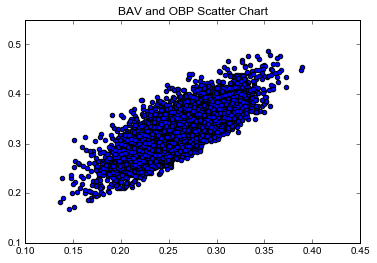

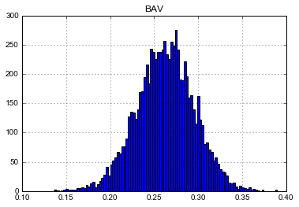

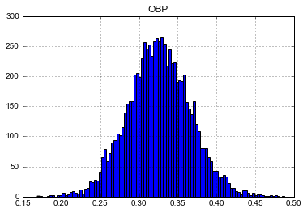

```python
# Batting data (missing values checked using .dropna method)

MLB = ["AL"]
AL_batting = batting[batting.lgID.isin(MLB)]
clean_AL_batting = AL_batting.dropna()
post72AL_batting = clean_AL_batting[clean_AL_batting.yearID >= 1973]
post72AL_batting = post72AL_batting[post72AL_batting.AB >= 130]


hit_handed_both = pd.merge(left=post72AL_batting, right=master2)

total = hit_handed_both['AB'].sum()

hit_handed_both['BAV'] = range(len(hit_handed_both))
hit_handed_both['OBP'] = range(len(hit_handed_both))

hit_handed_both['BAV'] = hit_handed_both['H']/(hit_handed_both['AB']*1.0)
hit_handed_both['OBP'] = (hit_handed_both['H'] + hit_handed_both['BB'] + hit_handed_both['HBP']) / ((hit_handed_both['AB'] \
    + hit_handed_both['BB'] + hit_handed_both['HBP'] + hit_handed_both['SH'] + hit_handed_both['SF']) *1.0)

plt.scatter(hit_handed_both['BAV'], hit_handed_both['OBP'])

plt.title('BAV and OBP Scatter Chart')

print hit_handed_both.columns

BAVgb = hit_handed_both.groupby(['yearID','bats'], as_index=False).mean()

BAVgb.apply(lambda x: x)

#BAVgb.plot(kind='line', column=['BAV'], title='Batting Average by Year')
#BAVgp[['BAV']].line(by='bats')
#BAVgp.plot()

#plt.show

print hit_handed_both.hist('BAV', bins=100)
print hit_handed_both.hist('OBP', bins=100)

hit_handed_left = hit_handed_both[hit_handed_both.throws == 'L']
hit_handed_right = hit_handed_both[hit_handed_both.throws == 'R']
```

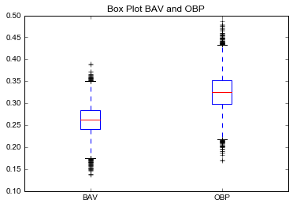

```python
hit_handed_both[['BAV','OBP']].plot(kind="box", title='Box Plot BAV and OBP')
plt.show()
```

```python
# calculates batting average for large datasets

def BAV(df1):
    hits = df1['H'].sum()
    atbats = df1['AB'].sum()
    BAV = (hits*1.0)/(atbats*1.0)

    return BAV

print BAV(hit_handed_left), "post-72 BAV AL lefties"
print BAV(hit_handed_right), "post-72 BAV AL righties"
print BAV(hit_handed_both), "post-72 BAV AL"
print "\n"
```

```
0.275119456804 post-72 BAV AL lefties
0.266809499408 post-72 BAV AL righties
0.268096272289 post-72 BAV AL
```

```python
#calculates on-base percentage for large datasets

def OBP(df1):
    numerator = (df1['H'].sum() + df1['BB'].sum() + df1['HBP'].sum())
    denominator = (df1['AB'].sum() + df1['BB'].sum() + df1['HBP'].sum() + df1['SH'].sum() + df1['SF'].sum())
    OBP = (numerator*1.0) / (denominator)

    return OBP

print OBP(hit_handed_left), "post-72 OBP AL lefties"
print OBP(hit_handed_right), "post-72 OBP AL righties"
print OBP(hit_handed_both), "post-72 OBP AL"
```

```
0.344263899577 post-72 OBP AL lefties
0.330841676565 post-72 OBP AL righties
0.332929617636 post-72 OBP AL
```

```python
# calculates home runs per at bat for large datasets

def hero(df1):
    homers = df1['HR'].sum()
    atbats = df1['AB'].sum()
    hero_factor = homers/atbats

    return hero_factor

print hero(hit_handed_left), "lefties post-72 homers per atbat, AL"
print hero(hit_handed_right), "righties post-72 homers per atbat, AL"
```

```
0.0304974464689 lefties post-72 homers per atbat, AL
0.0288590303464 righties post-72 homers per atbat, AL
```

```python
# calculates strikeouts per at bat

def goat(df1):
    kays = df1['SO'].sum()
    atbats = df1['AB'].sum()
    goat_factor = kays/atbats

    return goat_factor

print goat(hit_handed_left), "lefties post-72 K's per atbat, AL"
print goat(hit_handed_right), "righties post-72 K's per atbat, AL"
```

```
0.162067570695 lefties post-72 K's per atbat, AL
0.168879900413 righties post-72 K's per atbat, AL
```

### 3.2 Batters vs. Pitchers and Handedness

The lefty advantage in batting outlined above, though small, is clear. So then, why not field a team entirely of lefties? To push the analysis one step further, this section looks at handedness in the batter vs. pitcher confrontation. What are the comparative strengths of lefty and right batters against lefty and righty pitchers? There are four logical combinations: LHP vs. LHB (left handed pitcher vs. left-handed batter), LHP vs. RHB, RHP vs. LHB, RHP vs. RHB.

The outputs of this analysis are summarized in the tables and charts shown below for batting average (BAV) and on-base percentage (OBP). The most striking result is the success that lefty hitters have with righty pitchers and righty hitters have with lefty pitchers. Batters succeed much more frequently against pitchers with opposite-hand dominance than those who share a dominant hand. Lefty batters have trouble with lefty pitchers. Righty batters have trouble with righty pitchers. Success is situation-dependent, and because of roster limits and the rules of the game managers cannot always have the type of match-up that is optimal for their team.

| RHP | .264 | .253 |
| --- | --- | --- |
| LHP | .241 | .266 |
|  | LHB | RHB |

| RHP | .335 | .309 |
| --- | --- | --- |
| LHP | .305 | .332 |
|  | LHB | RHB |

Pitch release point, relative sight angles, time elapsed catching sight of the ball and other factors have been mentioned as potential drivers drivers of the phenomenon captured here. Left and righty batters co-exist because *pitchers* are right and left handed.

```python
# calculates batting average for the 4 logical lefty-righty pitcher and batter combinations

def split_BAV(df1):

    RHPRHB = SITU[SITU.SIT == 'RHPRHB']
    BAVRHPRHB = BAV(RHPRHB)

    RHPLHB = SITU[SITU.SIT == 'RHPLHB']
    BAVRHPLHB = BAV(RHPLHB)

    LHPRHB = SITU[SITU.SIT == 'LHPRHB']
    BAVLHPRHB = BAV(LHPRHB)

    LHPLHB = SITU[SITU.SIT == 'LHPLHB']
    BAVLHPLHB = BAV(LHPLHB)

    return BAVRHPRHB, BAVRHPLHB, BAVLHPRHB, BAVLHPLHB


print split_BAV(SITU)
```

```
(0.25385959339263026, 0.2643387688594477, 0.26649636313952096, 0.24191501663175125)
```

```python
# calculates on-base percentage for the 4 logical lefty-righty pitcher and batter combinations


def split_OBP(df1):

    RHPRHB = SITU[SITU.SIT == 'RHPRHB']
    OBPRHPRHB = OBP(RHPRHB)

    RHPLHB = SITU[SITU.SIT == 'RHPLHB']
    OBPRHPLHB = OBP(RHPLHB)

    LHPRHB = SITU[SITU.SIT == 'LHPRHB']
    OBPLHPRHB = OBP(LHPRHB)

    LHPLHB = SITU[SITU.SIT == 'LHPLHB']
    OBPLHPLHB = OBP(LHPLHB)

    return OBPRHPRHB, OBPRHPLHB, OBPLHPRHB, OBPLHPLHB


print split_OBP(SITU)
```

```
(0.3093925584210851, 0.33506652677319615, 0.33260177049126627, 0.30567785388281316)
```

```
array([<matplotlib.axes._subplots.AxesSubplot object at 0x125008bd0>,
       <matplotlib.axes._subplots.AxesSubplot object at 0x130902650>], dtype=object)
```

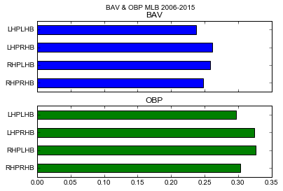

```python
chartdata = {'Mix': ['RHPRHB', 'RHPLHB', 'LHPRHB', 'LHPLHB'],
             'BAV': [0.248, 0.258, 0.261, 0.237],
             'OBP': [0.303, 0.326, 0.324, 0.297]}

frame = DataFrame(chartdata,index=mix)

%matplotlib inline

frame.plot(kind='barh', subplots = 2, legend=False, title ="BAV & OBP MLB 2006-2015")
```

## Conclusion

The analysis conducted here shows that lefties have a small but clear advantage in overall batting performancee in both batting average (BAV) and on-base percentage (OBP). Two addditional factors, homers per at bat (the hero factor) and strikeouts per at bat (the goat factor) added further evidence for this slight but real lefty dominance. The dataset is large and reliable and the basic measures are simple and undisputed. Because the data are from the American Leagie post-1973, they reflect "pure hitting," by definition excluding traditional elements of play (still prevalent in the National League) that could cloud the results.

If lefty hitters are dominant, why not field an all-lefty lineup? The answer is found in looking at a second variable, handedness in pitching. While lefty batters do well against righty pitchers, they perform relatively poorly against lefty pitchers. In fact, the variation in performance given potential combinations of lefty and righty batters and pitchers presents fans with uncounted chances for second guessing and prognisticating. Managers earn their paychecks because success is situation-dependent, a matter of trying to get the hitter you want up at the plate against a pitcher that might be vulnerable. Both the scatter chart and the histograms show, moreover, that there is enough variation in outcomes around the averages that results are far from predictable in any given situation. All this unpredictability gives fans something to talk about, hope for, and blather about forever after the game.

Since success over the course of a season for any given batter depends on the relative mix of pitchers of both types in the league, the continued existence of a small (but real!) superiority of lefties overall could be explained by the composition of the league's pitching staff. Genetics (and league rules) mean that there are only so many lefty arms available to pitch. The dataset used to look at this particular question was not as strong as the data supporting the rest of the analysis because I could not find or create a purely post-1973 batting splits dataset. Additional work on the data is required to make any truly comprehensive conclusions about this interesting question.